# Figure 2

11 October 2023

Skip to the final figure

Currently in post only: Bottom legend Equals in panel titles (cannot use with facet_wrap label_parsed)

# Data Preparation

Importing the whole brain cosinor statistics and merging into one table.

```r
# Child usage must import this data and libraries
source("code/setup.R")

meandf <- read_csv("data/available_upon_request/whole_brain_data.csv") |> filter(dx == 0)
WB_Scosinor <- read_rds("output/WB_S-cosinor.rds")
WB_Gcosinor <- read_rds("output/WB_G-cosinor.rds")
WB_AA <- read_rds("output/WB_AA.rds")

# Body weight results
weight_Scosinor <- read_rds("output/body_weight/weight_S-cosinor_dx0.rds")
weight_Gcosinor <- read_rds("output/body_weight/weight_G-cosinor_dx0.rds")
weight_AA <- read_rds("output/body_weight/weight_AA_dx0.rds")
weights <-
  read_csv("data/available_upon_request/weights_kg.csv") |>
  filter(dx == 0) |>
  mutate(ltime = ifelse(session_is_day2(session, time), time + 24, time))
```

# Figure 2a: Raw data

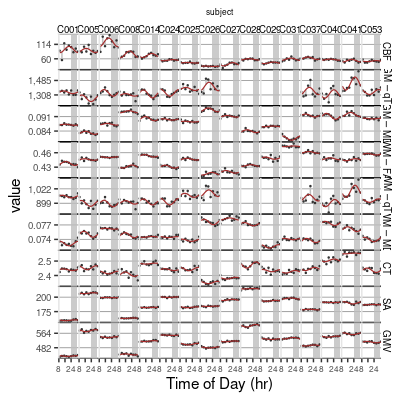

```r
meandf <-
  meandf |>
  mutate(measure = factor(measure, levels = fig1_modord)) |>
  arrange(measure)

wb_raw_data_mainfig_gg <- function(meandf,
                                   WB_Scosinor,
                                   fig1_modord) {
  labmap <-
    meandf |> select(measure) |> unique() |>
    ungroup() |>
    arrange(match(measure, fig1_modord)) |>
    mutate(label = factor(measure,
      ordered = T, levels = fig1_modord,
      labels = int2extlab[measure]
    )) |>
    select(measure, label) |>
    unique()


  meandf |>
    inner_join(WB_Scosinor) |>
    mutate(fitted = cosinor_pred(ltime, amplitude, acrophase, mesor)) |>
    inner_join(labmap) |>
    ggplot(aes(ltime, value, group = subject)) +
    guides(linetype = guide_legend(expression(p[S]))) +
    night_rect() +
    geom_segment(aes(xend = ltime, yend = fitted), color = "grey") +
    geom_point(size = 0.2, color = colors$raw_data) +
    geom_smooth(
      linewidth = 0.4, method = "lm", formula = y ~ sinpi(x / 12) + cospi(x / 12),
      color = colors$ssc, se = F
    ) +
    facet_grid(label ~ subject,
      scales = "free",
      labeller = label_parsed
    ) +
    theme(strip.text.y = element_text(angle = -90)) +
    theme(panel.spacing.x = unit(0, "lines")) +
    theme(panel.spacing.y = unit(0, "lines")) +
    theme(axis.text.x = element_text(size = 6)) +
    theme(
      panel.grid.minor.x = element_blank(),
      panel.grid.major.y = element_line(color = "grey60", size = 0.3),
      panel.grid.major.x = element_blank(),
      panel.grid.minor.y = element_line(color = "black", size = 0.5),
      panel.border = element_rect(color = NA),
      plot.title = element_text(size = 6, hjust = 0.5)
    ) +
    ggtitle("subject") +
    xlab("Time of Day (hr)") +
    geom_vline(xintercept = 8, color = "grey90") +
    scale_y_continuous(
      breaks = function(x) c(x[1] + diff(x) * 0.3, x[2] - diff(x) * 0.3),
      labels = my_val_formatter,
      minor_breaks = function(x) x
    ) +
    scale_x_continuous(
      breaks = c(8, 16, 24),
      labels = c(8, "", 24),
      limits = c(8, 36)
    ) +
    coord_cartesian(xlim = c(8, 32)) +
    theme_condense()
}
f2a <- wb_raw_data_mainfig_gg(meandf, WB_Scosinor, fig1_modord)
f2a
```

# Figure 2b: Polar plot

Distribution of acrophase estimates from 16 individuals with acrophases estimated on n=9 scans. G-cosinor result overlaid with 95% CI.

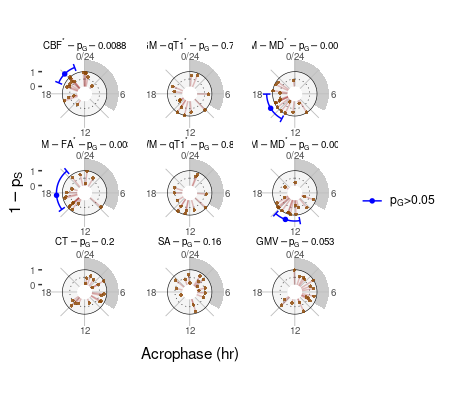

```r
# Impure function (fig1_modord)
wb_polar_mainfig_gg <- function(WB_Scosinor, WB_AA, WB_Gcosinor, fig1_modord) {
  labmap <-
    WB_AA |>
    inner_join(WB_Gcosinor |> ungroup()) |>
    ungroup() |>
    arrange(match(measure, fig1_modord)) |>
    mutate(label = factor(measure,
      ordered = T, levels = fig1_modord[fig1_modord %in% measure],
      labels = paste0(
        int2extlab[measure],
        ifelse(p < 0.05, "^`*`", ""), " - p[G] -",
        my_val_formatter(pvalue)
      )
    )) |>
    select(measure, label) |>
    unique()

  # For CI plotting
  # Expand CI into two segments when crossing 24:00
  thispcr <- WB_Gcosinor
  if (WB_Gcosinor$acro_u[1] > 24) {
    if (WB_Gcosinorpcr$acrophase > 24) thispcr$acrophase <- WB_Gcosinor$acrophase %% 24
    tmp <- rbind(thispcr, thispcr)
    tmp$acro_u[1] <- 24
    tmp$acro_l[2] <- 0
    tmp$acro_u[2] <- tmp$acro_u[2] %% 24
    thispcr <- tmp
  }
  if (WB_Gcosinor$acro_l[1] < 0) {
    if (WB_Gcosinor$acrophase > 24) thispcr$acrophase <- WB_Gcosinor$acrophase %% 24
    tmp <- rbind(thispcr, thispcr)
    tmp$acro_l[1] <- tmp$acro_l[1] %% 24
    tmp$acro_u[1] <- 24
    tmp$acro_l[2] <- 0
    tmp$acro_u[2] <- tmp$acro_u[2] %% 24
    thispcr <- tmp
  }

  WB_Scosinor |>
    inner_join(labmap) |>
    ggplot(aes(acrophase, 1 - pvalue)) +
    # Build plot area
    night_rect_early() +
    annotate(geom = "rect", xmin = 0, xmax = 24, ymin = 0, ymax = 1, alpha = 1, color = NA, fill = "whitesmoke") +
    annotate(geom = "rect", xmin = 0, xmax = 24, ymin = -Inf, ymax = 0, fill = "white") +
    annotate(
      geom = "segment", x = seq(0, 24, 3), y = 1.8, yend = 0, xend = seq(0, 24, 3),
      color = "grey", size = 0.3
    ) +
    scale_y_continuous(breaks = c(0, 1), limits = c(-0.5, 1.8)) +
    geom_hline(yintercept = 1, color = "black", size = 0.2) +
    geom_hline(yintercept = 0.5, color = "black", size = 0.2, linetype = 3) +
    geom_segment(aes(xend = acrophase, yend = 0), color = colors$ssc, alpha = 0.3) +
    # Colors$scc not accurate for some reason...
    geom_point(
      shape = 21, stroke = 0, fill = "darkorange4", alpha = 0.8,
      color = "transparent", size = 1.2
    ) +
    # G-cosinor
    geom_point(
      data = thispcr |> filter(pvalue < 0.05) |> inner_join(labmap),
      aes(acrophase, 1.4, color = ifelse(pvalue < 0.05, "p[G]<0.05", "p[G]>0.05")), size = 1.2
    ) +
    geom_errorbar(
      data = thispcr |> filter(pvalue < 0.05) |> inner_join(labmap),
      aes(
        xmin = acro_u, xmax = acro_l, y = 1.4,
        color = ifelse(pvalue < 0.05, "p[G]<0.05", "p[G]>0.05")
      ), width = 0.5
    ) +
    facet_wrap(label ~ ., nrow = 3, labeller = label_parsed) +
    theme(
      panel.border = element_blank(),
      panel.background = element_blank(),
      panel.grid = element_blank(),
      panel.spacing.x = unit(0, "line")
    ) +
    coord_polar() +
    theme(
      panel.grid.minor.x = element_blank(),
      panel.grid.minor.y = element_blank(),
      panel.grid.major.x = element_blank()
    ) +
    xlab("Acrophase (hr)") +
    ylab(expression(1 - p[S])) +
    scale_color_manual(
      labels = c(
        bquote(p[G] * ">0.05"),
        bquote(p[G] * "<0.05")
      ),
      values = c("p[G]>0.05" = "white", "p[G]<0.05" = colors$gcos_sig)
    ) +
    guides(color = guide_legend("")) +
    scale_x_continuous(limits = c(0, 24), breaks = seq(0, 24, 6)) +
    guides(size = guide_legend(expression(-log10(p[S])))) +
    theme(panel.spacing = unit(0, "lines")) +
    theme(
      panel.border = element_blank(),
      panel.background = element_blank(),
      # Legend
      legend.title.align = 0,
      legend.position = "right",
      legend.title = element_text(size = 8, vjust = 0, hjust = -3),
      panel.spacing.x = unit(1, "line"),
      panel.grid = element_blank()
    ) +
    theme_condense()
}

# (Partial) Source Data
fig2bSD <-
  WB_Gcosinor |>
  select(measure,pvalue,acrophase,acro_l,acro_u)
write_csv(fig2bSD |> mutate(measure=int2extlab[measure]),
          "output/source_data/Figure_2b_partial.csv")

f2b <- wb_polar_mainfig_gg(WB_Scosinor, WB_AA, fig2bSD, fig1_modord)
f2b
```

# Figure 2c: Unnormalized G-cosinor overlay

An additional illustration of the amplitude compared to interindividual variation

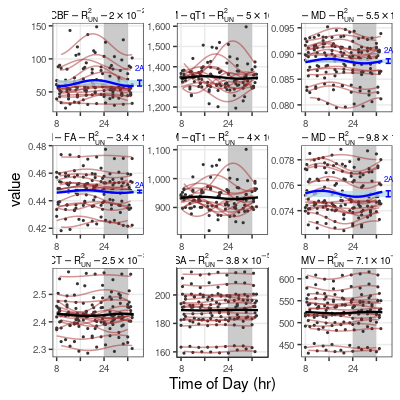

```r
# library(ggpubr) TODO: what's it for?
wb_unnorm_gcos <- function(WB_Gcosinor, meandf, fig1_modord) {
  # Create label for each metric
  labmap <-
    WB_Gcosinor |>
    ungroup() |>
    arrange(match(measure, fig1_modord)) |>
    mutate(label = factor(measure,
      ordered = T, levels = fig1_modord,
      labels = paste0(
        int2extlab[measure], "-R[UN]^2-",
        my_val_formatter(rsq, doparse = FALSE)
      )
    )) |>
    select(measure, label) |>
    unique()

  # Getting data for gcos predictions
  gcossim <- WB_Gcosinor |>
    select(measure, MESOR, amplitude, acrophase, pvalue) |>
    group_by(measure) |>
    nest() |>
    mutate(tmp = map(data, function(x) {
      t <- 8:34
      data.frame(
        value = cosinor_pred(
          t, as.numeric(x[1, 2]),
          as.numeric(x[1, 3]), as.numeric(x[1, 1])
        ),
        ltime = t, subject = "Cohort", pvalue = x$pvalue
      )
    })) |>
    unnest(tmp)

  meandf |>
    inner_join(labmap) |>
    ggplot() +
    night_rect() +
    geom_point(aes(ltime, value), size = 0.4, color = colors$raw_data) +
    stat_smooth_cosinor(aes(ltime, value, group = subject), se = F, alpha = 0.5, color = colors$ssc) +
    geom_rect(
      data = WB_Gcosinor |> filter(pvalue < 0.05) |> inner_join(labmap),
      aes(
        xmin = 8, xmax = 39, x = 0, y = MESOR,
        ymin = MESOR - amplitude, ymax = MESOR + amplitude
      ),
      fill = "lightblue", alpha = 0.7
    ) +
    geom_errorbar(
      data = WB_Gcosinor |> filter(pvalue < 0.05) |> inner_join(labmap),
      aes(x = 36, y = MESOR, ymin = MESOR - amplitude, ymax = MESOR + amplitude),
      color = "blue", width = 1.75
    ) +
    geom_text(
      data = WB_Gcosinor |> filter(pvalue < 0.05) |> inner_join(labmap),
      aes(label = "2A", x = 36, y = MESOR + amplitude * 5), size = 2,
      color = "blue"
    ) +
    geom_line(
      data = gcossim |> inner_join(labmap),
      aes(ltime, value, color = ifelse(pvalue < 0.05, "p[G]<0.05", "p[G]>0.05")), size = 0.8
    ) +
    scale_color_manual(
      labels = c(
        bquote(p[G] * ">0.05"),
        bquote(p[G] * "<0.05")
      ),
      values = c("p[G]>0.05" = "black", "p[G]<0.05" = colors$gcos_sig)
    ) +
    guides(color = "none") +
    facet_wrap(label ~ ., scales = "free", labeller = label_parsed) +
    theme(panel.spacing = unit(0.1, "line")) +
    theme(panel.grid.minor = element_blank()) +
    xlab("Time of Day (hr)") +
    scale_x_continuous(
      breaks = c(8, 16, 24, 32),
      labels = c(8, "", 24, ""),
      limits = c(8, NA)
    ) +
    scale_y_continuous(labels = my_val_formatter) +
    coord_cartesian(xlim = c(8, 36)) +
    theme_condense()
}

# (Partial) Source Data
fig2cSD <-
  WB_Gcosinor |>
  select(measure,pvalue,amplitude,acrophase,MESOR,rsq)
write_csv(fig2cSD |> mutate(measure=int2extlab[measure]),
          "output/source_data/Figure_2c_partial.csv")

ampoverlay_p <- wb_unnorm_gcos(fig2cSD, meandf, fig1_modord)
ampoverlay_p
```

# Figure 2d: De-meaned G-cosinor

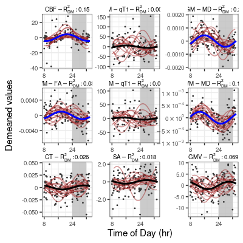

```r
wb_norm_gcos <- function(WB_Gcosinor, meandf, fig1_modord) {
  labmap <-
    WB_Gcosinor |>
    ungroup() |>
    arrange(match(measure, fig1_modord)) |>
    mutate(label = factor(measure,
      ordered = T, levels = fig1_modord,
      labels = paste0(
        int2extlab[measure], " - R[DM]^2 :",
        my_val_formatter(rsqdm)
      )
    )) |>
    select(measure, label) |>
    unique()

  gcos_preds <- WB_Gcosinor |>
    mutate(fitted = list(data.frame(
      t = 8:34,
      y_pred = cosinor_pred(8:34, amplitude, acrophase)
    ))) |>
    unnest(fitted) |>
    inner_join(labmap)

  meandf |>
    group_by(measure, subject) |>
    mutate(value = scale(value, scale = FALSE)) |>
    inner_join(labmap) |>
    ggplot(aes(ltime, value, group = NA)) +
    night_rect() +
    geom_point(size = 0.3, color = colors$raw_data) +
    xlab("Time of Day (hr)") +
    ylab("Demeaned values") +
    scale_x_continuous(
      breaks = c(8, 16, 24, 32),
      labels = c(8, "", 24, ""),
      limits = c(8, 34)
    ) +
    scale_y_continuous(labels = my_val_formatter) +
    stat_smooth_cosinor(aes(group = subject), se = F, alpha = 0.5, color = colors$ssc) +
    geom_line(data = gcos_preds, aes(t, y_pred,
      color = ifelse(pvalue < 0.05, "p[G]<0.05", "p[G]>0.05")
    ), size = 1) +
    scale_color_manual(
      labels = c(
        bquote(p[G] * ">0.05"),
        bquote(p[G] * "<0.05")
      ),
      values = c("p[G]>0.05" = "black", "p[G]<0.05" = colors$gcos_sig)
    ) +
    guides(color = "none") +
    theme(panel.spacing = unit(0, "line")) +
    facet_wrap(nrow = 4, label ~ ., scales = "free", labeller = label_parsed) +
    theme_condense()
}

# (Partial) Source Data
fig2dSD <-
  WB_Gcosinor |>
  select(measure,pvalue,amplitude,acrophase,MESOR,rsqdm)
write_csv(fig2dSD |> mutate(measure=int2extlab[measure]),
          "output/source_data/Figure_2d_partial.csv")

Gcos_ondata_p <- wb_norm_gcos(fig2dSD, meandf, fig1_modord)
Gcos_ondata_p
```

# Weights

Reuse MRI metrics/code for weight

## Raw data

```r
rawlin_p <- wb_raw_data_mainfig_gg(
  weights |> mutate(measure = "weight", value = weight),
  weight_Scosinor, "weight"
)
rawlin_p
```

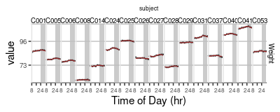

## Polar Acrophases

```r
polar_weights_p <- wb_polar_mainfig_gg(
  weight_Scosinor |> mutate(measure = "weight"),
  weight_AA,
  weight_Gcosinor |> mutate(measure = "weight"),
  "weight"
)
polar_weights_p
```

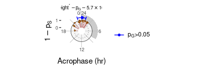

## Un-normalized S/G cosinor fits

```r
Gcos_un_weights_p <- wb_unnorm_gcos(
  weight_Gcosinor |> mutate(measure = "weight"),
  weights |> mutate(measure = "weight", value = weight),
  "weight"
)
Gcos_un_weights_p
```

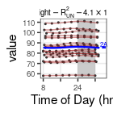

## De-meaned S/G cosinor

```r
Gcos_weights_p <- wb_norm_gcos(
  weight_Gcosinor |> mutate(measure = "weight"),
  weights |> mutate(measure = "weight", value = weight),
  "weight"
)
Gcos_weights_p
```

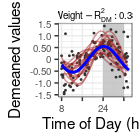

# Figures

## Figure 2

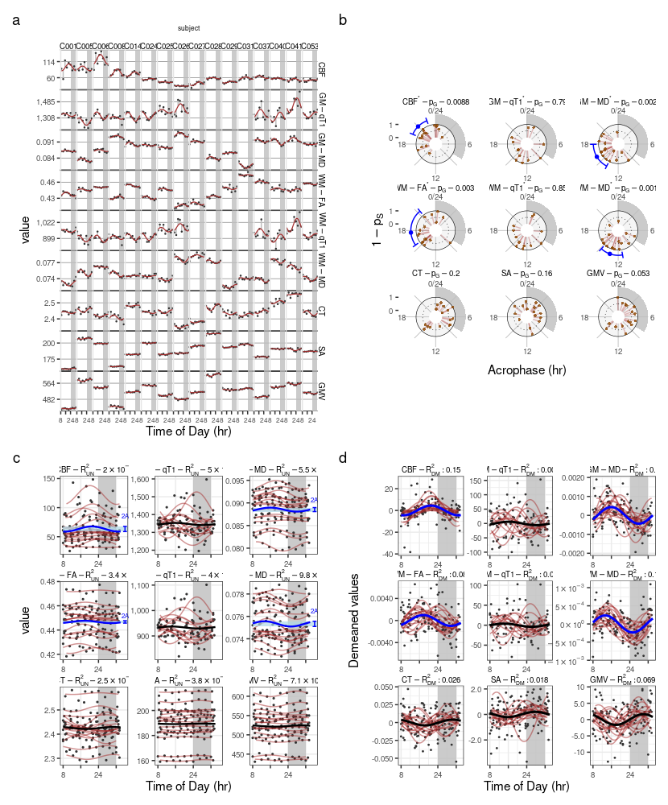

```r
f2a +
  #-next
  f2b + guides(color = "none") +
  #-next
  ampoverlay_p + guides(color = "none") +
  #-next
  Gcos_ondata_p + guides(color = "none") +
  #-patchwork
  plot_layout(design = "AAABBB
                          AAABBB
                          AAABBB
                          AAABBB
                          AAABBB
                          CCCDDD
                          CCCDDD
                          CCCDDD
                          CCCDDD
                          ") +
  plot_annotation(tag_levels = "a") +
  plot_layout(guides = "collect") & theme_condense()
```

## Figure Sbody-weight

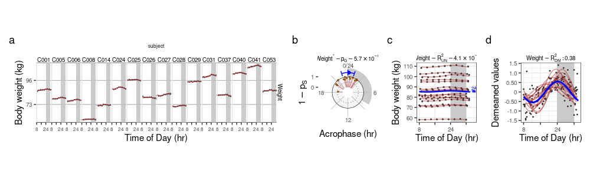

```r
  #-next
  rawlin_p + ylab("Body weight (kg)") +
  #-next
  polar_weights_p + guides(color = "none") +
  #-next
  Gcos_un_weights_p + ylab("Body weight (kg)") +
  #-next
  Gcos_weights_p+
  plot_layout(design = "AAAABCD") +
  plot_annotation(tag_levels = "a") +
  plot_layout(guides = "collect") & theme_condense()
```

**Click to see page metadata**

Computation Started: `2023-10-11 20:02:22`

Finished in `54.218 secs`

**Git Log**

No git history available for this page

**Packages**

[output not shown]

[output cut: 122 more lines]

**System Information**

|  | systemInfo |
| --- | --- |
| version | R version 4.1.3 (2022-03-10) |
| platform | x86_64-pc-linux-gnu (64-bit) |
| locale | en_US.UTF-8 |
| OS | Ubuntu 20.04.6 LTS |
| UI | X11 |

**Scikick Configuration**

```bash
cat scikick.yml
```

[output not shown]

[output cut: 33 more lines]

```
  singularity: /external/EPIGENETICS/SCRATCH/automator/share/singularity/shared3.img
version_info:
  snakemake: 6.3.0
  ruamel.yaml: 0.16.5
  scikick: 0.2.0
# Optional site theme customization
output:
  BiocStyle::html_document:
    code_folding: show
    theme: readable
    toc_float: true
    toc: true
    number_sections: false
    toc_depth: 5
    self_contained: true
```

**Functions**

acro2complex

```r
function (acro, per = 24)
{
    z <- complex(real = cos(acro/per * 2 * pi), imaginary = sin(acro/per *
        2 * pi))
    return(z)
}
```

ampacro2cos

```r
function (amp, acro, per = 24)
amp * cos(acro/per * 2 * pi)
```

ampacro2sin

```r
function (amp, acro, per = 24)
amp * sin(acro/per * 2 * pi)
```

circamean

```r
function (x, ...)
{
    ret <- {
        function(x) (x * 24/(2 * pi))%%24
    }(Arg(mean(acro2complex(x))))
    return(ret)
}
```

circdist

```r
function (acro1, acro2, per = 24)
{
    tmp <- (acro1 - acro2)%%per
    idx <- which(tmp > (per/2))
    tmp[idx] <- tmp[idx] - per
    return(tmp)
}
```

coord_circpolar

```r
function (...)
{
    list(coord_polar(...), scale_x_continuous(limits = c(0, 24),
        breaks = seq(0, 24, 3)), scale_y_continuous(limits = c(-1,
        NA)), theme(panel.grid.minor.x = element_blank(), panel.grid.minor.y = element_blank(),
        panel.grid.major.x = element_blank()), geom_hline(yintercept = 0,
        color = "grey"))
}
```

cosinor_pred

```r
function (time, A, acro, mesor = 0, per = 24)
{
    mesor + A * cos((time - acro) * 2 * pi/per)
}
<bytecode: 0x558799333498>
```

dcast

```r
function (data, formula, fun.aggregate = NULL, ..., margins = NULL,
    subset = NULL, fill = NULL, drop = TRUE, value.var = guess_value(data))
{
    formula <- parse_formula(formula, names(data), value.var)
    if (length(formula) > 2) {
        stop("Dataframes have at most two output dimensions")
    }
    if (!is.null(margins)) {
        data <- add_margins(data, lapply(formula, names), margins)
    }
    res <- cast(data, formula, fun.aggregate, ..., subset = subset,
        fill = fill, drop = drop, value.var = value.var)
    data <- as.data.frame.matrix(res$data, stringsAsFactors = FALSE)
    names(data) <- array_names(res$labels[[2]])
    stopifnot(nrow(res$labels[[1]]) == nrow(data))
    cbind(res$labels[[1]], data)
}
<bytecode: 0x558773cf2ee8>
<environment: namespace:reshape2>
```

discoCosinor

```r
function (x, zts, per = 24)
{
    Y <- as.matrix(x)
    res <- lmCSmatNoNA(Y[NULL, ], zts, per)
    res[seq_len(nrow(Y)), ] <- NA
    obsinds <- t(!is.na(Y))
    obstypes <- unique(obsinds, MARGIN = 2)
    obstypes <- obstypes[, colSums(obstypes) > 2, drop = FALSE]
    for (i in seq_len(ncol(obstypes))) {
        inds <- colMeans(obsinds == obstypes[, i]) == 1
        res[inds, ] <- lmCSmatNoNA(Y[inds, obstypes[, i], drop = FALSE],
            zts[obstypes[, i]], per)
    }
    res
}
<bytecode: 0x5587843e6120>
<environment: namespace:DiscoRhythm>
```

discoPMcos

```r
function (x, period = 24, idname = NULL, alpha = 0.05)
{
    if (is.data.frame(x))
        x <- split(x, 1:nrow(x))
    isdup <- F
    if (nrow(x[[1]]) == 1) {
        isdup <- T
        x <- lapply(x, function(y) rbind(y, y))
    }
    betas <- sapply(x, function(a) a$sincoef)
    gammas <- sapply(x, function(a) a$coscoef)
    mesors <- sapply(x, function(a) a$mesor)
    beta <- rowMeans(betas)
    gamma <- rowMeans(gammas)
    MESOR <- rowMeans(mesors)
    amplitude <- sqrt(beta^2 + gamma^2)
    acrophase_rad <- atan2(beta, gamma)
    sdm <- matrixStats::rowSds(mesors)
    sdb <- matrixStats::rowSds(betas)
    sdy <- matrixStats::rowSds(gammas)
    covby <- diag(cov(t(betas), t(gammas)))
    k <- ncol(betas)
    denom <- amplitude^2 * k
    c22 <- (sdb^2 * beta^2 + 2 * covby * beta * gamma + sdy^2 *
        gamma^2)/denom
    c23 <- ((-1 * (sdb^2 - sdy^2)) * (beta * gamma) + covby *
        (beta^2 - gamma^2))/denom
    c33 <- (sdb^2 * gamma^2 - 2 * covby * beta * gamma + sdy^2 *
        beta^2)/denom
    t <- abs(qt(alpha/2, df = k - 1))
    mesoru <- MESOR + ((t * sdm)/sqrt(k))
    mesorl <- MESOR - ((t * sdm)/sqrt(k))
    ampu <- amplitude + (t * sqrt(c22))
    ampl <- amplitude - (t * sqrt(c22))
    tmp <- vapply(seq_along(ampu), function(i) {
        if (ampu[i] > 0 & ampl[i] < 0) {
            return(c(NA, NA))
        }
        dn <- amplitude[i]^2 - c22[i] * t^2
        crit <- t * sqrt(c33[i]) * sqrt(amplitude[i]^2 - (c22[i] *
            c33[i] - c23[i]^2) * (t^2/c33[i]))
        return(c(acrophase_rad[i] + atan((c23[i] * t^2 + crit)/dn),
            acrophase_rad[i] + atan((c23[i] * t^2 - crit)/dn)))
    }, numeric(2))
    fiu <- tmp[1, ]
    fil <- tmp[2, ]
    r <- diag(cor(t(betas), t(gammas)))
    frac1 <- (k * (k - 2))/(2 * (k - 1))
    frac2 <- 1/(1 - r^2)
    frac3 <- beta^2/sdb^2
    frac4 <- (beta * gamma)/(sdb * sdy)
    frac5 <- gamma^2/sdy^2
    brack <- frac3 - 2 * r * frac4 + frac5
    Fvalue <- frac1 * frac2 * brack
    df2 <- k - 2
    pvalue <- pf(q = Fvalue, df1 = 2, df2 = df2, lower.tail = F)
    ret <- data.frame(F = Fvalue, df1 = 2, df2 = k - 2, pvalue,
        qvalue = p.adjust(pvalue, "fdr"), MESOR, amplitude = amplitude,
        acrophase = (acrophase_rad/2/pi * period + period)%%period,
        MESOR_l = mesorl, MESOR_u = mesoru, amp_l = ampl, amp_u = ampu,
        acro_l = (fil/2/pi * period + period)%%period, acro_u = (fiu/2/pi *
            period + period)%%period)
    idx <- which(ret$acro_l > ret$acro_u)
    ret$acro_l[idx] <- ret$acro_l[idx] - period
    idx <- which((ret$acro_l < ret$acro & ret$acro_u < ret$acro))
    ret$acro_l[idx] <- ret$acro_l[idx] + period
    ret$acro_u[idx] <- ret$acro_u[idx] + period
    idx <- which((ret$acro_l > ret$acro & ret$acro_u > ret$acro))
    ret$acro_l[idx] <- ret$acro_l[idx] - period
    ret$acro_u[idx] <- ret$acro_u[idx] - period
    if (!is.null(idname)) {
        rownames(ret) <- x[[1]][[idname]]
    }
    else {
        rownames(ret) <- rownames(x[[1]])
    }
    if (isdup)
        ret <- ret[1, ]
    return(ret)
}
```

dx2lab

```r
function (x)
{
    return(ifelse(as.character(x) == "1", "BPD", "CNTRL"))
}
```

geom_smooth_cosinor

```r
function (...)
geom_smooth(method = "lm", formula = y ~ sinpi(x/12) + cospi(x/12),
    ...)
```

get_glasser_spatial_meta

```r
function ()
{
    meta <- readxl::read_xlsx("data/reference_files/MMP1_CSV_file.xlsx")
    meta <- meta %>% mutate(region = ifelse(region == "7Pl",
        "7PL", region)) %>% mutate(regionName = ifelse(regionName ==
        "7Pl_L", "7PL_L", regionName)) %>% mutate(regionName = ifelse(regionName ==
        "7Pl_R", "7PL_R", regionName))
    meta$roi <- paste(meta$LR, gsub("_[LR]", "", meta$regionName),
        "ROI", sep = "_")
    meta$hemi <- ifelse(meta$LR == "L", "left", "right")
    return(meta)
}
```

get_icbm_spatial_meta

```r
function ()
{
    meta <- readxl::read_xlsx("data/reference_files/JHU_ICBM81.xlsx")
    meta <- meta[-c(1:2), ]
    meta$region <- meta$label %>% gsub(" ", "_", .) %>% gsub("\\(",
        "", .) %>% gsub("\\)", "", .) %>% gsub("\\/", "or", .)
    meta$roi <- meta$region
    meta <- meta %>% mutate(region = gsub(" R$", "", label)) %>%
        mutate(region = gsub(" L$", "", region)) %>% filter(region !=
        "Unclassified")
    return(meta)
}
```

get_subcor_ggseg_atlas

```r
function ()
{
    library(ggseg)
    library(ggsegGlasser)
    meta <- get_glasser_spatial_meta()
    pdf <- full_join(unique(select(read_csv("data/available_upon_request/processed_ROI_data.csv") %>%
        filter(measure == "cbf"), roi)), meta) %>% filter(is.na(`z-cog`)) %>%
        rename(label = roi) %>% ungroup() %>% select(label)
    myaseg <- aseg
    myaseg$data <- myaseg$data %>% filter(label %in% pdf$label)
    return(myaseg)
}
```

groupWiseSummaryPvalTable

```r
function (dat, as_kable = FALSE)
{
    ret <- dat %>% group_by(grp) %>% summarize(res = list(summaryPvalTable(pvalue))) %>%
        unnest(res) %>% mutate(val = paste0(percent, " (", count,
        ")")) %>% reshape2::dcast(level ~ grp, value.var = "val")
    if (as_kable)
        ret <- knitr::kable(ret)
    return(ret)
}
```

icbm_preprocess

```r
function (df)
{
    df %>% filter(region != "Fornix (column and body of fornix)") %>%
        mutate(roi = str_pad(index, 3, pad = "0"))
}
```

my_val_formatter

```r
function (x, doparse = T, mf = T, ...)
{
    ifelse(x > 10000 | (x > 0 & x < 0.001) | (x < 0 & x > -0.001),
        {
            txt1 <- (scales::scientific_format(digits = 2))(x)
            if (mf) {
                txt <- gsub("e\\+*", " %*% 10^", txt1)
            }
            else {
                return(txt1)
            }
            if (doparse) {
                return(parse(text = txt))
            }
            else {
                return(txt)
            }
        }, formatC(x, format = "fg", digits = 2, flag = "#",
            big.mark = ","))
}
<bytecode: 0x55878381c060>
```

myfmt

```r
function (x)
formatC(x, digits = 2)
```

myfmt2

```r
function (x)
my_val_formatter(x, mf = F)
```

night_rect

```r
function ()
{
    annotate(geom = "rect", ymin = -Inf, ymax = Inf, xmin = 24,
        xmax = 32, alpha = 0.8, fill = "grey", color = NA)
}
<bytecode: 0x55879c5d0398>
```

night_rect_early

```r
function ()
{
    annotate(geom = "rect", ymin = -Inf, ymax = Inf, xmin = 0,
        xmax = 8, alpha = 0.8, fill = "grey", color = NA)
}
<bytecode: 0x55879a638958>
```

night_recty

```r
function ()
{
    annotate(geom = "rect", xmin = -Inf, xmax = Inf, ymin = 24,
        ymax = 32, alpha = 0.8, fill = "grey", color = NA)
}
```

night_recty_early

```r
function ()
{
    annotate(geom = "rect", xmin = -Inf, xmax = Inf, ymin = 0,
        ymax = 8, alpha = 0.8, fill = "grey", color = NA)
}
```

pqlabs

```r
function (p = NULL, q = NULL)
{
    if (!is.null(p) & is.null(q)) {
        lab <- rep("p>0.05", length(p))
        lab[p < 0.05] <- "p<0.05"
        levs <- c("p>0.05", "p<0.05")
    }
    else if (is.null(p) & !is.null(q)) {
        lab <- rep("q>0.05", length(q))
        lab[q < 0.05] <- "q<0.05"
        levs <- c("q>0.05", "q<0.05")
    }
    else if (!is.null(p) & !is.null(q)) {
        stopifnot(length(p) == length(q))
        lab <- rep("p>0.05", length(p))
        lab[p < 0.05] <- "p<0.05"
        lab[q < 0.05] <- "q<0.05"
        levs <- c("p>0.05", "p<0.05", "q<0.05")
    }
    return(factor(lab, levels = levs))
}
```

rsqGcos

```r
function (pmr, dat)
{
    predat2 <- group_by(mutate(group_by(inner_join(pmr, dat),
        measure, roi, subject), dmval = value - mean(value)),
        measure, roi)
    rsqdf <- summarize(mutate(mutate(mutate(mutate(predat2, sr1 = (value -
        cosinor_pred(time, amplitude, acrophase, MESOR))^2),
        ts1 = (value - MESOR)^2), sr2 = (dmval - cosinor_pred(time,
        amplitude, acrophase, 0))^2), ts2 = (dmval - 0)^2), rsq = 1 -
        sum(sr1)/sum(ts1), rsqdm = 1 - sum(sr2)/sum(ts2))
    return(inner_join(pmr, rsqdf))
}
```

scale_alpha_fgbg

```r
function (alpha_bg = 0.3, ...)
scale_alpha_manual(values = c(`TRUE` = 1, `FALSE` = alpha_bg,
    ...))
```

scale_color_clock

```r
function (rot = 0, ...)
scale_color_gradientn(colors = rainbow(24)[((1:24) - 1 + rot)%%24 +
    1], limits = c(0, 24), ...)
```

scale_color_dx

```r
function ()
{
    scale_color_manual(values = c(`1` = colors$dx1, `0` = colors$dx0))
}
```

scale_color_dxlab

```r
function (...)
{
    scale_color_manual(values = c(BPD = colors$dx1, CNTRL = colors$dx0,
        ...))
}
```

scale_color_fgbg

```r
function (fgcol = "red", ...)
scale_color_manual(values = c(`TRUE` = fgcol, `FALSE` = "grey20",
    ...))
```

scale_fill_clock

```r
function (rot = 0, ...)
scale_fill_gradientn(colors = rainbow(24)[((1:24) - 1 + rot)%%24 +
    1], limits = c(0, 24), ...)
```

scale_fill_dx

```r
function ()
{
    scale_fill_manual(values = c(`1` = colors$dx1, `0` = colors$dx0))
}
```

scale_fill_dxlab

```r
function ()
{
    scale_fill_manual(values = c(BPD = colors$dx1, CNTRL = colors$dx0))
}
```

scale_fill_fgbg

```r
function (fgcol = "red", ...)
scale_fill_manual(values = c(`TRUE` = fgcol, `FALSE` = "grey20",
    ...))
```

scale_x_circ

```r
function ()
scale_x_continuous(limits = c(0, 24), breaks = seq(0, 24, 6))
```

session_is_day2

```r
function (session, time)
{
    (session >= 6 & session <= 9) & time < 12
}
```

sincos2acro

```r
function (sin, cos, per = 24)
{
    (atan2(sin, cos)/2/pi * per + per)%%per
}
<bytecode: 0x558784af64d8>
<environment: namespace:DiscoRhythm>
```

sincos2amp

```r
function (sin, cos)
sqrt(sin^2 + cos^2)
<bytecode: 0x558784aff8a0>
<environment: namespace:DiscoRhythm>
```

stat_smooth_cosinor

```r
function (...)
stat_smooth(geom = "line", method = "lm", formula = y ~ sinpi(x/12) +
    cospi(x/12), ...)
<bytecode: 0x55878a888f88>
```

summaryPvalTable

```r
function (p, as_kable = FALSE)
{
    ps <- list()
    ps[[1]] <- p < 0.05
    ps[[2]] <- p < 0.01
    ps[[3]] <- p.adjust(p, method = "fdr") < 0.05
    ps[[4]] <- p.adjust(p, method = "bonferroni") < 0.05
    levs <- c("p < 0.05", "p < 0.01", "FDR", "Bonferroni")
    perc <- sapply(ps, function(p) round(mean(p, na.rm = TRUE),
        4)) * 100
    sums <- sapply(ps, function(p) sum(p, na.rm = TRUE))
    ret <- data.frame(level = levs, count = sums, percent = paste0(perc,
        "%"), stringsAsFactors = FALSE)
    if (as_kable)
        ret <- knitr::kable(ret)
    return(ret)
}
```

theme_condense

```r
function ()
{
    list(theme(strip.background = element_rect(color = "white",
        fill = "white")), theme(strip.text = element_text(size = 7,
        color = "black", margin = margin(b = 0, t = 0))), theme(axis.text = element_text(size = 7)))
}
<bytecode: 0x558799144458>
```

theme_condense_legend

```r
function ()
{
    list(guides(shape = guide_legend(override.aes = list(size = 0.3))),
        guides(color = guide_legend(override.aes = list(size = 0.3))),
        guides(fill = guide_legend(override.aes = list(size = 0.3))),
        theme(legend.title = element_text(size = 6), legend.text = element_text(size = 6),
            legend.key.size = unit(0.3, "cm")))
}
```

**Next (Project Map)**

[figure not shown]